# Sequence Processing and Conserved Taxonomy Assignment

Progress report #3

Phylotype & OTU-based approach

Updated: 2018-10-29 20:54:17

# PROGRESS REPORT 3

# Sequence Processing and Conserved Taxonomy Assignment

The clean paired-end sequences that passed the preprocessing trimming and filtering were processed and classified using mothur-based phylotype and OTU-based approaches as described (Schloss et al. 2009). This step enables investigators to review merged sequences to determine if expected length is in-line with the targeted 16S rRNA gene region. Lack of good overlapping region could results into too many sequences that are wrong and the effect will be propagated in the downstream analysis. High quality sequences align in the same region when searched against a reference template.

**Descriptive statistics**

## Sequence assembly

|  | Length | Overlap_Length | MisMatches |
| --- | --- | --- | --- |
|  | Min. : 14 | Min. : 0.0 | Min. : 0.000 |
|  | 1st Qu.:252 | 1st Qu.:102.0 | 1st Qu.: 0.000 |
|  | Median :252 | Median :153.0 | Median : 0.000 |
|  | Mean :241 | Mean :137.7 | Mean : 1.385 |
|  | 3rd Qu.:253 | 3rd Qu.:173.0 | 3rd Qu.: 0.000 |
|  | Max. :500 | Max. :250.0 | Max. :116.000 |

## Sequence alignment

|  | QueryLength | PairwiseAlignmentLength | SimBtwnQuery&Template |
| --- | --- | --- | --- |
|  | Min. : 16.0 | Min. : 1.0 | Min. : 50.00 |
|  | 1st Qu.:252.0 | 1st Qu.:252.0 | 1st Qu.: 96.05 |
|  | Median :253.0 | Median :253.0 | Median : 98.41 |
|  | Mean :244.4 | Mean :244.5 | Mean : 96.19 |
|  | 3rd Qu.:253.0 | 3rd Qu.:253.0 | 3rd Qu.: 99.21 |
|  | Max. :310.0 | Max. :315.0 | Max. :100.00 |

## Distribution of processed sequences

- Bar plots
- Box plots
- Density plots
- Histogram plots

### Stacked barplot

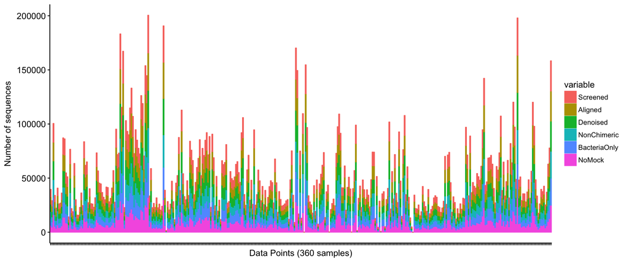

Figure x: Stacked barplots of processed sequences grouped by processing variable

### Boxplots grouped by processing variable

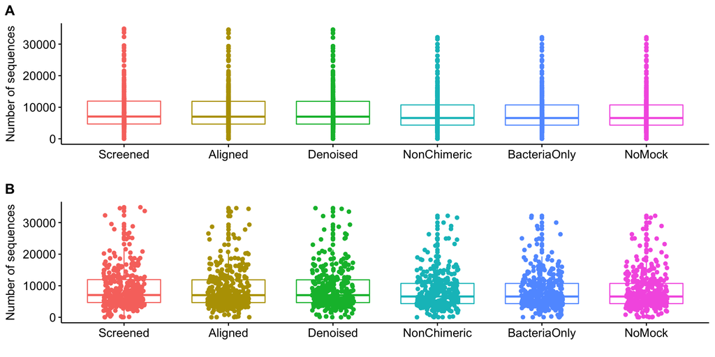

### Boxplots rouped by sex and time variable

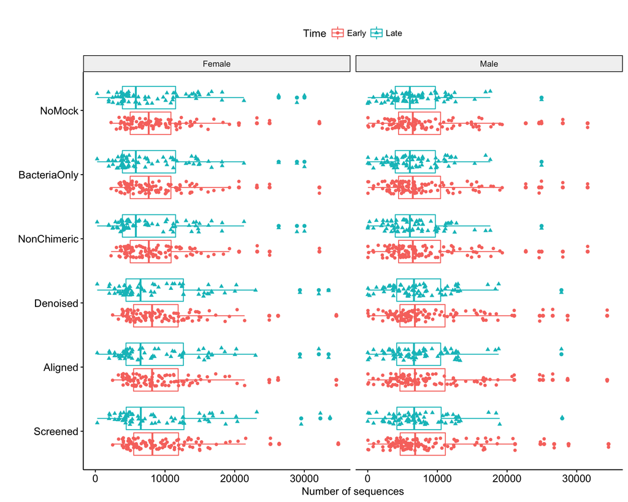

### Density and histogram plots

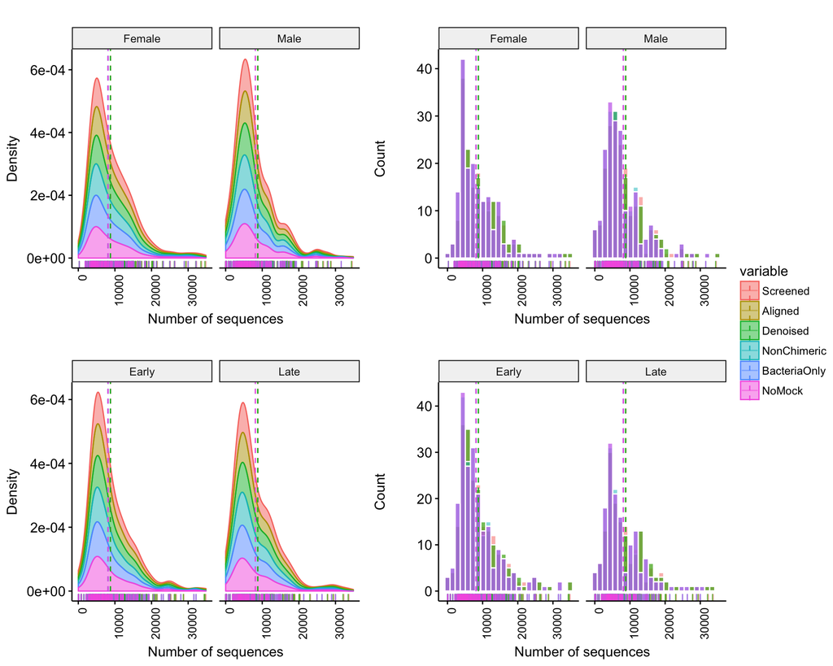

# Assignment of conserved taxonomy to OTUs

In summary the taxonomy data was generated with high stringent quality control parameters. Initially, 2,920,782 quality-checked sequences were classified at 80% identity against 16S rRNA gene sequences deposited in version 132 of SILVA rRNA database as described in the previous section. In OTUbased approach in particular, the clustering done by opticlust algorithm in-built in-built in mothur yielded reliable output based on the high metrics generated and a low FDR = 0.002 obtained (Table 1).

Table x: Statistical parameters calculated from the OTU-based classification method

| Parameter | Value |
| --- | --- |
| cutoff | 0.2 |
| Sensitivity | 0.998 |
| Specificity | 0.999 |
| PPV | 0.998 |
| NPV | 0.999 |
| Accuracy | 0.999 |
| MCC | 0.997 |
| F1score | 0.998 |
| FDR | 0.002 |

## Taxonomy data integration

- Integrating output obtained from diverse methods could be a robust way for profiling complex microbial communities present in a given sample.

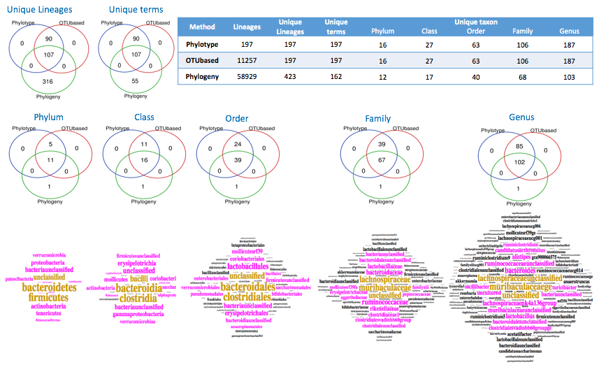

Figure x: Venn diagram showing taxa identified with 100% confidence using three classification methods commonly used in mothur platform. Software used (Van de Peer 2018)

# Posible questions

### At sequence processing

- QN1: Do the paired sequences overlap as expected?
- QN2: Are there sequences to be removed from the analysis based on sequence length?
- QN3: Does the dorminant length match the targeted region of 16S rRNA gene?
- QN4: Are the representative sequences too few or too many? Note that too many non-redundant sequences may results from poor overlapping between forward and reverse reads. Review before proceeding to avoid misleading conclusions.

### At sequence classification

- QN1: What taxonomic classifier should be used? Think of need to develop and use custom classifier that suits the study objectives.
- QN2: Are there sequences assigned to non-bacterial taxonomic lineages?
- QN3: Should the matches to non-bacterial lineages be removed from further analysis?
- QN4: …….?

### At error estimation

- QN1: Is the error too high to cause rejection of the results results?
- QN2: …….?
- QN3: …….?
- QN4: …….?

### At OTU clustering and conserved taxonomy assignment

- QN1: What cutoff should be used?
- QN2: …….?
- QN3: …….?
- QN4: …….?

Schloss, P D, S L Westcott, T Ryabin, J R Hall, M Hartmann, E B Hollister, R A Lesniewski, et al. 2009. “Introducing mothur: open-source, platform-independent, community-supported software for describing and comparing microbial communities.” *Appl Environ Microbiol* 75 (23): 7537–41. https://doi.org/10.1128/AEM.01541-09.

Van de Peer. 2018. “Calculate and draw custom Venn diagrams.” http://bioinformatics.psb.ugent.be/webtools/Venn/.